# California Housing price regression and LIME

The report describes XGBoost and Multi Layer Perceptron learning results on California Housing dataset and decomposition of trained models sample predictions using LIME. The dataset contains 8 features describing blocks of houses. MedHouseVal is an explained variable containing medium house value in $100 000. Below there are quartiles for all of the features:

|  | MedInc | HouseAge | AveRooms | AveBedrms | Population | AveOccup | Latitude | Longitude |
| --- | --- | --- | --- | --- | --- | --- | --- | --- |
| **0.00** | 0.50 | 1.0 | 0.89 | 0.33 | 3.0 | 0.69 | 32.55 | -124.35 |
| **0.25** | 2.57 | 18.0 | 4.45 | 1.01 | 789.0 | 2.43 | 33.93 | -121.81 |
| **0.50** | 3.55 | 29.0 | 5.24 | 1.05 | 1167.0 | 2.82 | 34.26 | -118.51 |
| **0.75** | 4.77 | 37.0 | 6.06 | 1.10 | 1726.0 | 3.28 | 37.72 | -118.01 |
| **1.00** | 15.00 | 52.0 | 141.91 | 25.64 | 35682.0 | 1243.33 | 41.95 | -114.31 |

XGBoost model was trained with 1000 estimators, max depth equal to 5 and default settings from sklearn. On a validation set it got the following statistics: MSE=0.20, R^2=0.84. Below there are validation results:

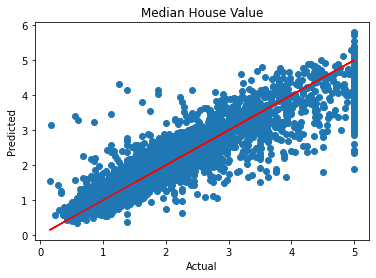

| MedInc | HouseAge | AveRooms | AveBedrms | Population | AveOccup | Latitude | Longitude | MedHouseVal | XGBPred |
| --- | --- | --- | --- | --- | --- | --- | --- | --- | --- |
| 1.27 | 47.0 | 5.19 | 1.15 | 1346.0 | 3.35 | 38.54 | -121.47 | 0.57 | 0.51 |
| 2.62 | 33.0 | 3.96 | 1.00 | 2650.0 | 3.64 | 34.00 | -118.11 | 1.79 | 1.73 |
| 10.55 | 28.0 | 7.84 | 1.04 | 1101.0 | 2.82 | 33.77 | -118.46 | 5.00 | 5.10 |

Below there is a decomposition of selected predictions using LIME with with quartile discretization over features. For the lower price, latitude greater than 3rd quartile had the largest negative impact on the price. Longitude between 1st and 2nd quartile slightly increased the price and most of other features had a small negative impact.

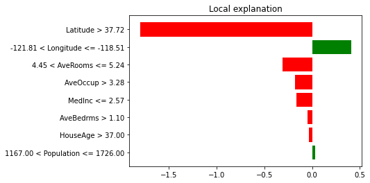

In the medium price case, coordinates influenced the price in the opposite way - latitude increased the price and longitude decreased it. Another important factor was low average number of rooms which decreased the predicted value.

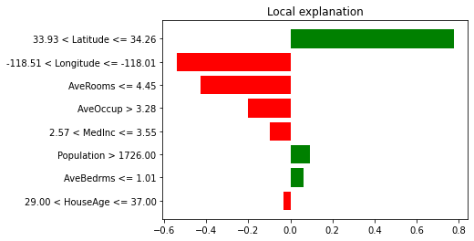

For the largest price, latitude had the greatest positive impact and longitude had quite large negative impact but it was the third factor. The second important feature was high average number of rooms. Median income was also large and influenced the house value positively.

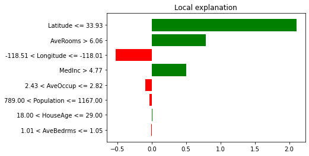

Comparing the selected observations, the geographical coordinates seems to be the most important factor influencing prices of selected blocks of houses. For two lower prices, average number of rooms is low and decreases the price but for the higher price that feature contains high value increasing the median house price.

The second trained model was MLP with 3 hidden layers (64, 64, 64). These are its results on a validation set: MSE=0.28, R^2=0.79, and all predictions on this set below:

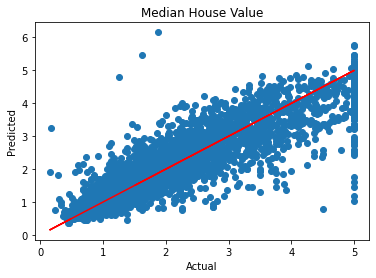

Below there are the same 3 selected observations with MLP prediction results:

| MedInc | HouseAge | AveRooms | AveBedrms | Population | AveOccup | Latitude | Longitude | MedHouseVal | MLPPred |
| --- | --- | --- | --- | --- | --- | --- | --- | --- | --- |
| 1.27 | 47.0 | 5.19 | 1.15 | 1346.0 | 3.35 | 38.54 | -121.47 | 0.57 | 0.78 |
| 2.62 | 33.0 | 3.96 | 1.00 | 2650.0 | 3.64 | 34.00 | -118.11 | 1.79 | 1.67 |
| 10.55 | 28.0 | 7.84 | 1.04 | 1101.0 | 2.82 | 33.77 | -118.46 | 5.00 | 5.02 |

Below there are results of a similar LIME decomposition for the lower, midium and higher price (in this order), but using MLP model. As we can see, latitude and longitude are also of great importance for this model for selected observations. The biggest change is that average occupancy significantly decreases the prediction results for lower and medium price.

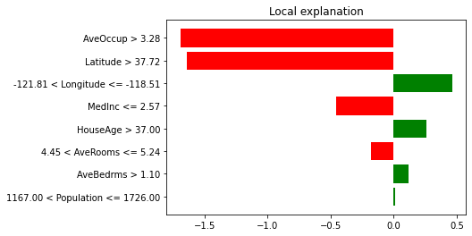

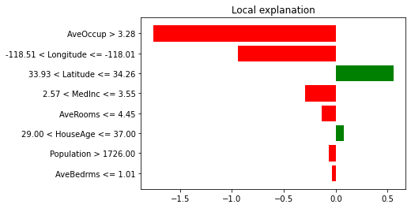

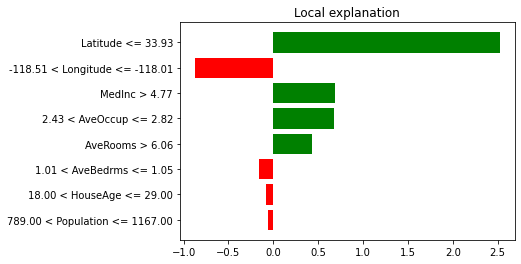

## Appendix

```python
from matplotlib import pyplot
from lime.lime_tabular import LimeTabularExplainer
from xgboost import XGBRegressor

from sklearn import metrics
from sklearn.model_selection import train_test_split
from sklearn.datasets import fetch_california_housing
from sklearn.preprocessing import MinMaxScaler
from sklearn.pipeline import make_pipeline
from sklearn.neural_network import MLPRegressor

def evaluate(testY, predY):
    pyplot.plot(testY, testY, 'r')
    pyplot.scatter(testY, predY)
    pyplot.title('Median House Value');
    pyplot.xlabel('Actual')
    pyplot.ylabel('Predicted')
    pyplot.show()

    print()
    print("MSE:", metrics.mean_squared_error(testY, predY))
    print("MAE:", metrics.mean_absolute_error(testY, predY))
    print("R2:", metrics.r2_score(testY, predY))
```

### Data loading

```python
X, y = fetch_california_housing(return_X_y=True, as_frame=True)
X_train, X_test, y_train, y_test = train_test_split(X, y, test_size=0.2, random_state=42)
```

```python
print('features:', X_train.shape[1])
print('X_train length:', X_train.shape[0])
print('X_test length:', X_test.shape[0])
```

```python
X_train.quantile([i / 4 for i in range(5)]).round(2)
```

### Training

#### XGBoost Regressor

```python
model_XGB = XGBRegressor(objective='reg:squarederror', n_estimators=1000, max_depth=5)
model_XGB.fit(X_train.values, y_train)
y_pred = model_XGB.predict(X_test.values)
evaluate(y_test, y_pred)
```

#### Multi Layer Perceptron

```python
model_MLP = make_pipeline(MinMaxScaler(), MLPRegressor((64, 64, 64), learning_rate='adaptive', max_iter=1000))
model_MLP.fit(X_train.values, y_train)
y_pred = model_MLP.predict(X_test.values)
evaluate(y_test, y_pred)
```

### Selecting observations

```python
data = X_test.copy()
data['MedHouseVal'] = y_test
data_selected = data.sort_values('MedHouseVal').iloc[[100, len(data) / 2, -100]]
X_selected = data_selected[X_test.columns]
data_selected['XGBPred'] = model_XGB.predict(X_selected.values)
data_selected['MLPPred'] = model_MLP.predict(X_selected.values)
XGB_selected = data_selected[list(data.columns) + ['XGBPred']]
MLP_selected = data_selected[list(data.columns) + ['MLPPred']]
```

```python
XGB_selected.round(2)
```

```python
MLP_selected.round(2)
```

### LIME

```python
explainer = LimeTabularExplainer(X_train.values, mode="regression", feature_names=X_train.columns.to_list(), discretize_continuous=True)
```

#### XGBoost

```python
for row in X_selected.values:
    exp = explainer.explain_instance(row, model_XGB.predict)
    exp.as_pyplot_figure()
```

#### Multi Layer Perceptron

```python
for row in X_selected.values:
    exp = explainer.explain_instance(row, model_MLP.predict)
    exp.as_pyplot_figure()
```